# Machine Learning: AllLife Bank Personal Loan Campaign

## Problem Statement

### Context

AllLife Bank is a US bank that has a growing customer base. The majority of these customers are liability customers (depositors) with varying sizes of deposits. The number of customers who are also borrowers (asset customers) is quite small, and the bank is interested in expanding this base rapidly to bring in more loan business and in the process, earn more through the interest on loans. In particular, the management wants to explore ways of converting its liability customers to personal loan customers (while retaining them as depositors).

A campaign that the bank ran last year for liability customers showed a healthy conversion rate of over 9% success. This has encouraged the retail marketing department to devise campaigns with better target marketing to increase the success ratio.

You as a Data scientist at AllLife bank have to build a model that will help the marketing department to identify the potential customers who have a higher probability of purchasing the loan.

### Objective

To predict whether a liability customer will buy personal loans, to understand which customer attributes are most significant in driving purchases, and identify which segment of customers to target more.

### Data Dictionary

- `ID`: Customer ID
- `Age`: Customer’s age in completed years
- `Experience`: #years of professional experience
- `Income`: Annual income of the customer (in thousand dollars)
- `ZIP Code`: Home Address ZIP code.
- `Family`: the Family size of the customer
- `CCAvg`: Average spending on credit cards per month (in thousand dollars)
- `Education`: Education Level. 1: Undergrad; 2: Graduate;3: Advanced/Professional
- `Mortgage`: Value of house mortgage if any. (in thousand dollars)
- `Personal_Loan`: Did this customer accept the personal loan offered in the last campaign? (0: No, 1: Yes)
- `Securities_Account`: Does the customer have securities account with the bank? (0: No, 1: Yes)
- `CD_Account`: Does the customer have a certificate of deposit (CD) account with the bank? (0: No, 1: Yes)
- `Online`: Do customers use internet banking facilities? (0: No, 1: Yes)
- `CreditCard`: Does the customer use a credit card issued by any other Bank (excluding All life Bank)? (0: No, 1: Yes)

## Importing necessary libraries

```python
# Installing the libraries with the specified version.
!pip install numpy==1.25.2 pandas==2.0.3 matplotlib==3.7.1 seaborn==0.13.1 scikit-learn==1.2.2 sklearn-pandas==2.2.0 -q --user
```

**Note**: *After running the above cell, kindly restart the notebook kernel and run all cells sequentially from the start again.*

```python
#Installing libary to suppress warnings
import warnings
warnings.filterwarnings("ignore")

# Installing libraries for reading & manipulating data
import numpy as np
import pandas as pd

# Installing libraries for data visualization
import seaborn as sns
import matplotlib.pyplot as plt

# Code to limit number of displayed columns
pd.set_option("display.max_columns",None)

# Code to limit number of displayed rows
pd.set_option("display.max_rows",300)

#Install library to split data
from sklearn.model_selection import train_test_split

# Installing libraries to build Decision tree model
from sklearn.tree import DecisionTreeClassifier
from sklearn import tree

#Installing library to tune different models
from sklearn.model_selection import GridSearchCV

#Installing different metric scores libraries
from sklearn.metrics import (f1_score, accuracy_score, recall_score, precision_score, confusion_matrix,make_scorer,)
```

## Loading the dataset

```python
# code to import drive into colab
from google.colab import drive
drive.mount('/content/drive')
```

```python
# Read Csv file from drive
pers_loan = pd.read_csv('/content/drive/MyDrive/PythonGreatLearning/Loan_Modelling.csv')
```

```python
# create a copy of this data into another variable to avoid changes to the original dataset
ldata = pers_loan.copy()
```

## Data Overview

- Observations
- Sanity checks

**Verify First & last rows of the dataset to validate if the data has been loaded properly**

```python
# Get first 5 rows
ldata.head()
```

|  | ID | Age | Experience | Income | ZIPCode | Family | CCAvg | Education | Mortgage | Personal_Loan | Securities_Account | CD_Account | Online | CreditCard |
| --- | --- | --- | --- | --- | --- | --- | --- | --- | --- | --- | --- | --- | --- | --- |
| 0 | 1 | 25 | 1 | 49 | 91107 | 4 | 1.6 | 1 | 0 | 0 | 1 | 0 | 0 | 0 |
| 1 | 2 | 45 | 19 | 34 | 90089 | 3 | 1.5 | 1 | 0 | 0 | 1 | 0 | 0 | 0 |
| 2 | 3 | 39 | 15 | 11 | 94720 | 1 | 1.0 | 1 | 0 | 0 | 0 | 0 | 0 | 0 |
| 3 | 4 | 35 | 9 | 100 | 94112 | 1 | 2.7 | 2 | 0 | 0 | 0 | 0 | 0 | 0 |
| 4 | 5 | 35 | 8 | 45 | 91330 | 4 | 1.0 | 2 | 0 | 0 | 0 | 0 | 0 | 1 |

```python
# Get last 5 rows
ldata.tail()
```

|  | ID | Age | Experience | Income | ZIPCode | Family | CCAvg | Education | Mortgage | Personal_Loan | Securities_Account | CD_Account | Online | CreditCard |
| --- | --- | --- | --- | --- | --- | --- | --- | --- | --- | --- | --- | --- | --- | --- |
| 4995 | 4996 | 29 | 3 | 40 | 92697 | 1 | 1.9 | 3 | 0 | 0 | 0 | 0 | 1 | 0 |
| 4996 | 4997 | 30 | 4 | 15 | 92037 | 4 | 0.4 | 1 | 85 | 0 | 0 | 0 | 1 | 0 |
| 4997 | 4998 | 63 | 39 | 24 | 93023 | 2 | 0.3 | 3 | 0 | 0 | 0 | 0 | 0 | 0 |
| 4998 | 4999 | 65 | 40 | 49 | 90034 | 3 | 0.5 | 2 | 0 | 0 | 0 | 0 | 1 | 0 |
| 4999 | 5000 | 28 | 4 | 83 | 92612 | 3 | 0.8 | 1 | 0 | 0 | 0 | 0 | 1 | 1 |

```python
# Get the number of features & data entries in the dataset using shape
ldata.shape
```

```
(5000, 14)
```

- There are 14 features in the dataset
- And 5000 entries for the data

**Validate the datatypes of the 14 features**

```python
ldata.info()
```

```
<class 'pandas.core.frame.DataFrame'>
RangeIndex: 5000 entries, 0 to 4999
Data columns (total 14 columns):
 #   Column              Non-Null Count  Dtype
---  ------              --------------  -----
 0   ID                  5000 non-null   int64
 1   Age                 5000 non-null   int64
 2   Experience          5000 non-null   int64
 3   Income              5000 non-null   int64
 4   ZIPCode             5000 non-null   int64
 5   Family              5000 non-null   int64
 6   CCAvg               5000 non-null   float64
 7   Education           5000 non-null   int64
 8   Mortgage            5000 non-null   int64
 9   Personal_Loan       5000 non-null   int64
 10  Securities_Account  5000 non-null   int64
 11  CD_Account          5000 non-null   int64
 12  Online              5000 non-null   int64
 13  CreditCard          5000 non-null   int64
dtypes: float64(1), int64(13)
memory usage: 547.0 KB
```

- We have 13 features of Int datatype & 1 feature of Float datatype
- From this we can notice tha all the features have 5000 Non-Null values which indicates no null values in the dataset

**Get the statistical summary of the dataset**

```python
ldata.describe().T
```

|  | count | mean | std | min | 25% | 50% | 75% | max |
| --- | --- | --- | --- | --- | --- | --- | --- | --- |
| ID | 5000.0 | 2500.500000 | 1443.520003 | 1.0 | 1250.75 | 2500.5 | 3750.25 | 5000.0 |
| Age | 5000.0 | 45.338400 | 11.463166 | 23.0 | 35.00 | 45.0 | 55.00 | 67.0 |
| Experience | 5000.0 | 20.104600 | 11.467954 | -3.0 | 10.00 | 20.0 | 30.00 | 43.0 |
| Income | 5000.0 | 73.774200 | 46.033729 | 8.0 | 39.00 | 64.0 | 98.00 | 224.0 |
| ZIPCode | 5000.0 | 93169.257000 | 1759.455086 | 90005.0 | 91911.00 | 93437.0 | 94608.00 | 96651.0 |
| Family | 5000.0 | 2.396400 | 1.147663 | 1.0 | 1.00 | 2.0 | 3.00 | 4.0 |
| CCAvg | 5000.0 | 1.937938 | 1.747659 | 0.0 | 0.70 | 1.5 | 2.50 | 10.0 |
| Education | 5000.0 | 1.881000 | 0.839869 | 1.0 | 1.00 | 2.0 | 3.00 | 3.0 |
| Mortgage | 5000.0 | 56.498800 | 101.713802 | 0.0 | 0.00 | 0.0 | 101.00 | 635.0 |
| Personal_Loan | 5000.0 | 0.096000 | 0.294621 | 0.0 | 0.00 | 0.0 | 0.00 | 1.0 |
| Securities_Account | 5000.0 | 0.104400 | 0.305809 | 0.0 | 0.00 | 0.0 | 0.00 | 1.0 |
| CD_Account | 5000.0 | 0.060400 | 0.238250 | 0.0 | 0.00 | 0.0 | 0.00 | 1.0 |
| Online | 5000.0 | 0.596800 | 0.490589 | 0.0 | 0.00 | 1.0 | 1.00 | 1.0 |
| CreditCard | 5000.0 | 0.294000 | 0.455637 | 0.0 | 0.00 | 0.0 | 1.00 | 1.0 |

Observations based on the above statistical summary

Dropping Columns

```python
#Let's drop ID column as it's unique value for each entry in the dataset and is not required for our data analysis
ldata.drop('ID', axis=1 , inplace=True)
```

```python
#Check for duplicates
ldata.duplicated().sum()
```

```
0
```

## Data Preprocessing

- Missing value treatment
- Feature engineering (if needed)
- Outlier detection and treatment (if needed)
- Preparing data for modeling
- Any other preprocessing steps (if needed)

**Missing Value treatment**

```python
ldata.isnull().sum()
```

```
Age                   0
Experience            0
Income                0
ZIPCode               0
Family                0
CCAvg                 0
Education             0
Mortgage              0
Personal_Loan         0
Securities_Account    0
CD_Account            0
Online                0
CreditCard            0
dtype: int64
```

No Missing values in the dataset

**Feature Engineering**

```python
# We have noticed ZIP code is of type integer which needs to be addressed
# Let's check number of unique values in the ZIP code variable
ldata['ZIPCode'].nunique()
```

```
467
```

```python
# Convert the ZIP code column datatype into string datatype
ldata['ZIPCode'] = ldata['ZIPCode'].astype(str)
ldata['ZIPCode'].dtype
```

```
dtype('O')
```

```python
#Let's extract the number of unique values if we extract first two digits of the ZIPCode

print('Number of Unique values if we extract first two digits of the ZIPCode', ldata['ZIPCode'].str[0:2].nunique())
```

```
Number of Unique values if we extract first two digits of the ZIPCode 7
```

```python
# Since we have identified 7 distinct ZIPCodes based after extracting the first two digits of the ZIPCode, we can convert them to Categorical type
ldata['ZIPCode'] = ldata['ZIPCode'].str[0:2]
ldata['ZIPCode'] = ldata['ZIPCode'].astype("category")
```

```python
ldata['ZIPCode'].dtype
```

```
CategoricalDtype(categories=['90', '91', '92', '93', '94', '95', '96'], ordered=False)
```

ZIPCode is converted into Categorical datatype

```python
#Similarly we have noticed few other variables in the dataset which are of categorical nature but were represented as Int types
# print all columns in the dataset
print(ldata.columns)
```

```
Index(['Age', 'Experience', 'Income', 'ZIPCode', 'Family', 'CCAvg',
       'Education', 'Mortgage', 'Personal_Loan', 'Securities_Account',
       'CD_Account', 'Online', 'CreditCard'],
      dtype='object')
```

```python
# Family, Education,Mortgage, Personal_Loan, Securities_Account, CD_Account, Online, CreditCard
# All of these variables can be converted into to Categorical type
categorical_cols = [ 'Education', 'Personal_Loan', 'Securities_Account', 'CD_Account', 'Online', 'CreditCard']
ldata[categorical_cols] = ldata[categorical_cols].astype('category')

# Let's verify if all of these columns
print(ldata['Education'].dtype)
print(ldata['Personal_Loan'].dtype)
print(ldata['Securities_Account'].dtype)
print(ldata['CD_Account'].dtype)
print(ldata['Online'].dtype)
print(ldata['CreditCard'].dtype)
```

```
category
category
category
category
category
category
```

**Addressing Anamolies in data**

```python
# As we have already seen experience column has minimum value as -3 which represents anamolies
# Let's understand how many unique values exists in the experience feature
print(ldata['Experience'].unique())
# Different Anamoly values in experience feature which are <0
print(ldata[ldata['Experience']<0]['Experience'].unique())
# count of Anamoly values in experience feature
ldata[ldata['Experience']<0]['Experience'].count()
```

```
[ 1 19 15  9  8 13 27 24 10 39  5 23 32 41 30 14 18 21 28 31 11 16 20 35
  6 25  7 12 26 37 17  2 36 29  3 22 -1 34  0 38 40 33  4 -2 42 -3 43]
[-1 -2 -3]
```

```
52
```

There are 52 rows in the dataset with a negative values in experience feature i.e.,-1,-2,-3

```python
# Let's correct experience column for these 52 rows
# In general to correct anamolies is to either replace them with Mean, Median or Mode. Since it's integer variable we can either compute Mean or median
# From the statistical summary , mean & median are close to each other , so let's compute with Median
print(ldata['Experience'].median())
ldata['Experience'].replace([-1,-2,-3], ldata['Experience'].median(), inplace=True)
```

```
20.0
```

```python
# Let's confirm if all the negative values in the experience column are replaced
ldata[ldata['Experience']<0].nunique()
```

```
Age                   0
Experience            0
Income                0
ZIPCode               0
Family                0
CCAvg                 0
Education             0
Mortgage              0
Personal_Loan         0
Securities_Account    0
CD_Account            0
Online                0
CreditCard            0
dtype: int64
```

All negative values are now treated

## Exploratory Data Analysis.

- EDA is an important part of any project involving data.
- It is important to investigate and understand the data better before building a model with it.
- A few questions have been mentioned below which will help you approach the analysis in the right manner and generate insights from the data.
- A thorough analysis of the data, in addition to the questions mentioned below, should be done.

**Questions**:

1. What is the distribution of mortgage attribute? Are there any noticeable patterns or outliers in the distribution?
2. How many customers have credit cards?
3. What are the attributes that have a strong correlation with the target attribute (personal loan)?
4. How does a customer's interest in purchasing a loan vary with their age?
5. How does a customer's interest in purchasing a loan vary with their education?

**Univariant Analysis**

```python
def histogram_boxplot(data, feature, figsize=(12, 7), kde=False, bins=None):
    """
    Boxplot and histogram combined

    data: dataframe
    feature: dataframe column
    figsize: size of figure (default (12,7))
    kde: whether to show the density curve (default False)
    bins: number of bins for histogram (default None)
    """
    f2, (ax_box2, ax_hist2) = plt.subplots(
        nrows=2,  # Number of rows of the subplot grid= 2
        sharex=True,  # x-axis will be shared among all subplots
        gridspec_kw={"height_ratios": (0.25, 0.75)},
        figsize=figsize,
    )  # creating the 2 subplots
    sns.boxplot(
        data=data, x=feature, ax=ax_box2, showmeans=True, color="violet"
    )  # boxplot will be created and a star will indicate the mean value of the column
    sns.histplot(
        data=data, x=feature, kde=kde, ax=ax_hist2, bins=bins, palette="winter"
    ) if bins else sns.histplot(
        data=data, x=feature, kde=kde, ax=ax_hist2
    )  # For histogram
    ax_hist2.axvline(
        data[feature].mean(), color="green", linestyle="--"
    )  # Add mean to the histogram
    ax_hist2.axvline(
        data[feature].median(), color="black", linestyle="-"
    )  # Add median to the histogram
```

```python
# function to create labeled barplots


def labeled_barplot(data, feature, perc=False, n=None):
    """
    Barplot with percentage at the top

    data: dataframe
    feature: dataframe column
    perc: whether to display percentages instead of count (default is False)
    n: displays the top n category levels (default is None, i.e., display all levels)
    """

    total = len(data[feature])  # length of the column
    count = data[feature].nunique()
    if n is None:
        plt.figure(figsize=(count + 1, 5))
    else:
        plt.figure(figsize=(n + 1, 5))

    plt.xticks(rotation=90, fontsize=15)
    ax = sns.countplot(
        data=data,
        x=feature,
        palette="Paired",
        order=data[feature].value_counts().index[:n].sort_values(),
    )

    for p in ax.patches:
        if perc == True:
            label = "{:.1f}%".format(
                100 * p.get_height() / total
            )  # percentage of each class of the category
        else:
            label = p.get_height()  # count of each level of the category

        x = p.get_x() + p.get_width() / 2  # width of the plot
        y = p.get_height()  # height of the plot

        ax.annotate(
            label,
            (x, y),
            ha="center",
            va="center",
            size=12,
            xytext=(0, 5),
            textcoords="offset points",
        )  # annotate the percentage

    plt.show()  # show the plot
```

**Observations on Age**

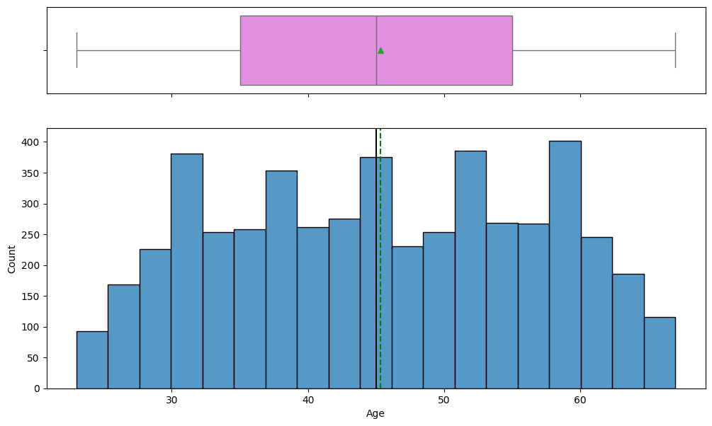

```python
histogram_boxplot(ldata,'Age')
```

- No Outliers in the Age Feature & data is uniformly distributed
- Minimum Age is 23 & Max age is 67 with Average as 45

**Observations on Experience**

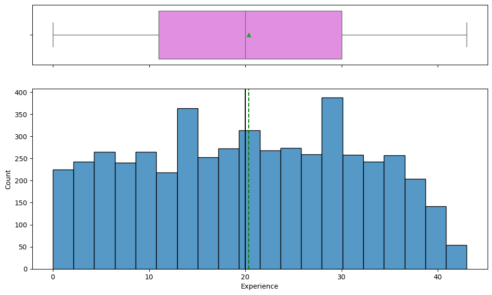

```python
histogram_boxplot(ldata,'Experience')
```

- Experience feature doesn't have any outliers & Data is almost uniformly distributed
- Minimum experience is 0 and maximum is 43 with mean approximately as 20.

**Observations on Income**

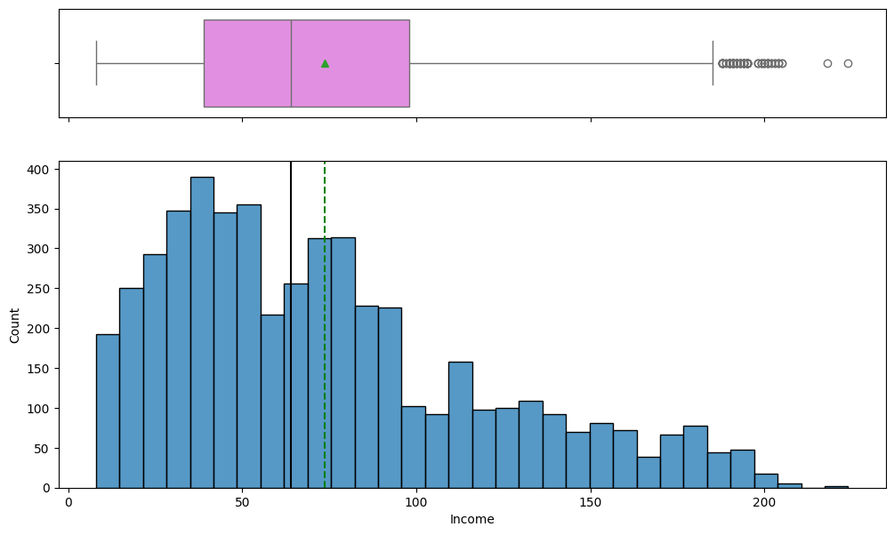

```python
histogram_boxplot(ldata,'Income')
```

**Observations on Family**

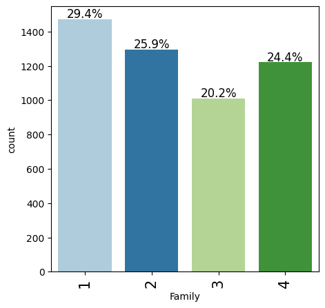

```python
labeled_barplot(ldata, "Family", perc=True)
```

- Majority of the customers have family size as 1(29.4%) followed by 2 (25.9%)

**Observations on CCAvg**

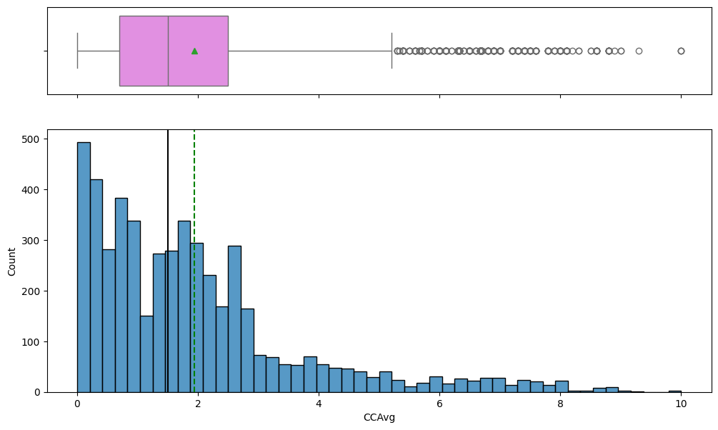

```python
histogram_boxplot(ldata,'CCAvg')
```

- The data is heavly right skewed with multiple outliers
- Minimum CCAvg is USD 0K & Maximum CCAvg is USD 10.0k with average as USD 1.9K

**Observations on Education**

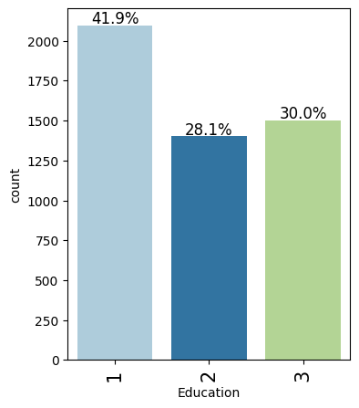

```python
labeled_barplot(ldata, "Education", perc=True)
```

- Most of the customers have Education as Undergrad(41.9%) followed by Advanced/Professional(30.0%), Graduate(28.1%)

**Observations on Mortgage**

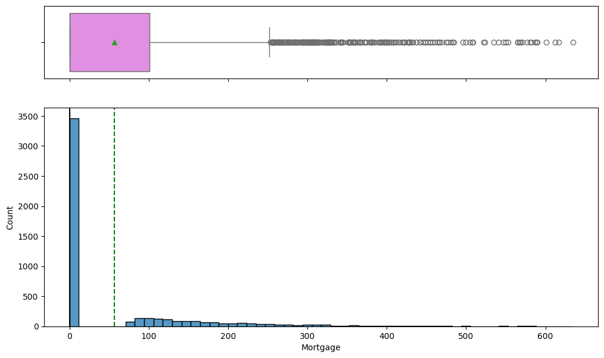

```python
histogram_boxplot(ldata,'Mortgage')
```

- Minimum value as **USD 0K**, Max is **USD 635K** & average is **USD 56K**
- Mortgage is heavily right skewed with multiple outliers

**Observations on Personal_Loan**

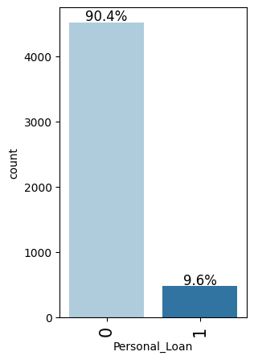

```python
labeled_barplot(ldata,'Personal_Loan',perc=True)
```

- 90.4% of the customers didn't accept loan in the last campaign
- 9.6% of the customers accepted the loan in the last campaign

Observations on Securities_Account

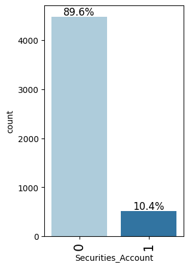

```python
labeled_barplot(ldata,'Securities_Account', perc=True)
```

- 89.6% customers don't have securities account with the bank
- 10.4% customers have securities account with the bank

**Observations on CD_Account**

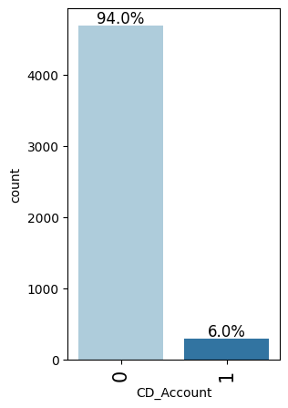

```python
labeled_barplot(ldata,'CD_Account', perc=True)
```

- 94% customers don't have certificate of deposit (CD) account with the bank
- 6% customers have certificate of deposit (CD) account with the bank

**Observations on Online**

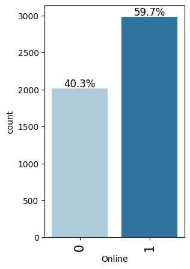

```python
labeled_barplot(ldata, 'Online', perc=True)
```

- 40.3% customers don't use internet banking facilities
- 59.7% customers use internet banking facilities

**Observations on CreditCard**

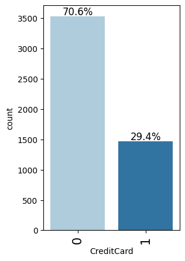

```python
labeled_barplot(ldata,'CreditCard',perc=True)
```

- 70.6% Customers don't have Credit Card issued by other bank
- 29.4% Customers have Credit Card issued by other bank

**Observations on ZIPCode**

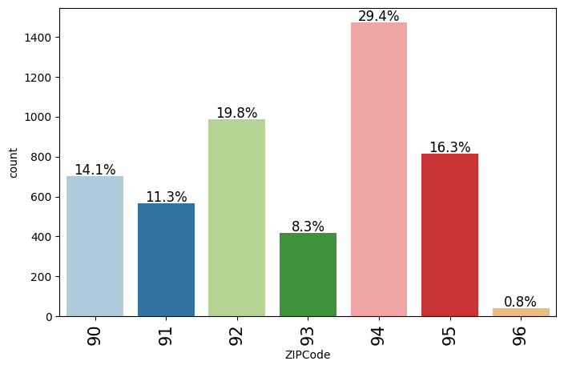

```python
labeled_barplot(ldata,'ZIPCode',perc=True)
```

- 29.4% of the customers belongs to the ZIPCode 94 followed by 19.8% with ZIPCode as 92

**BiVariate Analysis**

```python
def stacked_barplot(data, predictor, target):
    """
    Print the category counts and plot a stacked bar chart

    data: dataframe
    predictor: independent variable
    target: target variable
    """
    count = data[predictor].nunique()
    sorter = data[target].value_counts().index[-1]
    tab1 = pd.crosstab(data[predictor], data[target], margins=True).sort_values(
        by=sorter, ascending=False
    )
    print(tab1)
    print("-" * 120)
    tab = pd.crosstab(data[predictor], data[target], normalize="index").sort_values(
        by=sorter, ascending=False
    )
    tab.plot(kind="bar", stacked=True, figsize=(count + 5, 5))
    plt.legend(
        loc="lower left", frameon=False,
    )
    plt.legend(loc="upper left", bbox_to_anchor=(1, 1))
    plt.show()
```

```python
### function to plot distributions wrt target


def distribution_plot_wrt_target(data, predictor, target):

    fig, axs = plt.subplots(2, 2, figsize=(12, 10))

    target_uniq = data[target].unique()

    axs[0, 0].set_title("Distribution of target for target=" + str(target_uniq[0]))
    sns.histplot(
        data=data[data[target] == target_uniq[0]],
        x=predictor,
        kde=True,
        ax=axs[0, 0],
        color="teal",
        stat="density",
    )

    axs[0, 1].set_title("Distribution of target for target=" + str(target_uniq[1]))
    sns.histplot(
        data=data[data[target] == target_uniq[1]],
        x=predictor,
        kde=True,
        ax=axs[0, 1],
        color="orange",
        stat="density",
    )

    axs[1, 0].set_title("Boxplot w.r.t target")
    sns.boxplot(data=data, x=target, y=predictor, ax=axs[1, 0], palette="gist_rainbow")

    axs[1, 1].set_title("Boxplot (without outliers) w.r.t target")
    sns.boxplot(
        data=data,
        x=target,
        y=predictor,
        ax=axs[1, 1],
        showfliers=False,
        palette="gist_rainbow",
    )

    plt.tight_layout()
    plt.show()
```

**Correlation Check**

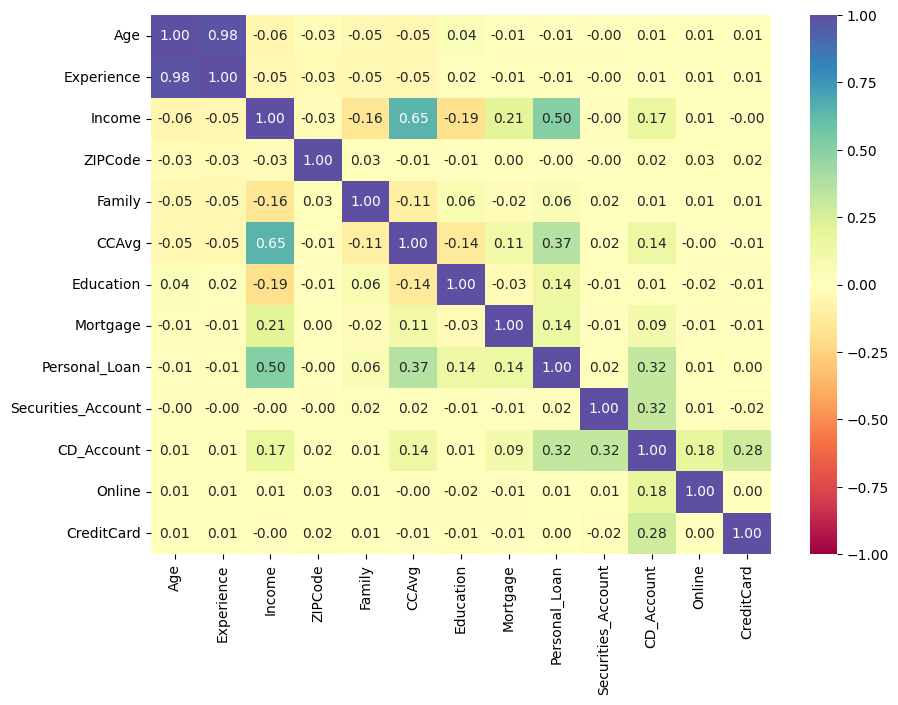

```python
plt.figure(figsize=(10,7))
sns.heatmap(ldata.corr(),vmax=1,vmin=-1,annot=True, cmap='Spectral',fmt='.2f')
plt.show()
```

- Correlation between Age & Experience is High
- Correlation between CCAvg & Income is good
- Income,CD_Account & CCAvg has good correlation with Personal_Loan while Family & Education have low correlation with Personal_Loan , ZIPCode & Personal_Loan doesn't have any correlation

**Let's check Customers interest in purchasing a loan with Numerical variables**

**Personal_Loan vs Age**

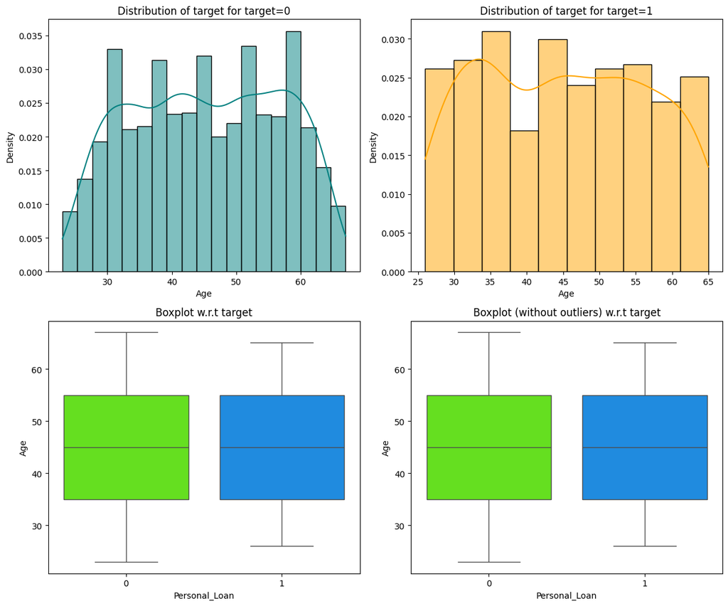

```python
distribution_plot_wrt_target(ldata,'Age','Personal_Loan')
```

- As observed from the heatmap correlation , we see the Age doesn't have correlation with the target_variable i.e, Personal_Loan

**Personal_Loan Vs Experience**

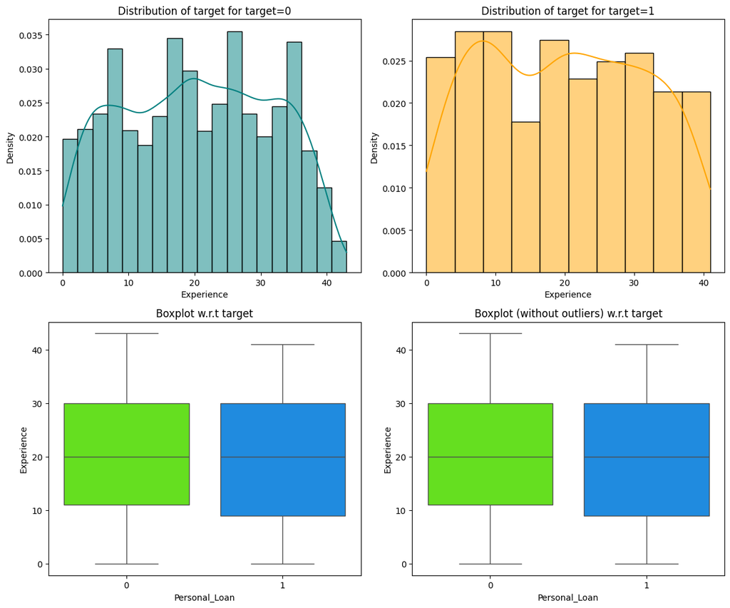

```python
distribution_plot_wrt_target(ldata,'Experience','Personal_Loan')
```

- Mean Experience of a customer accepting/not accepting loan is nearly 20
- As observed from the heatmap correlation , we see the Experience don't have correlation with the target_variable i.e, Personal_Loan

**Personal Loan Vs Income**

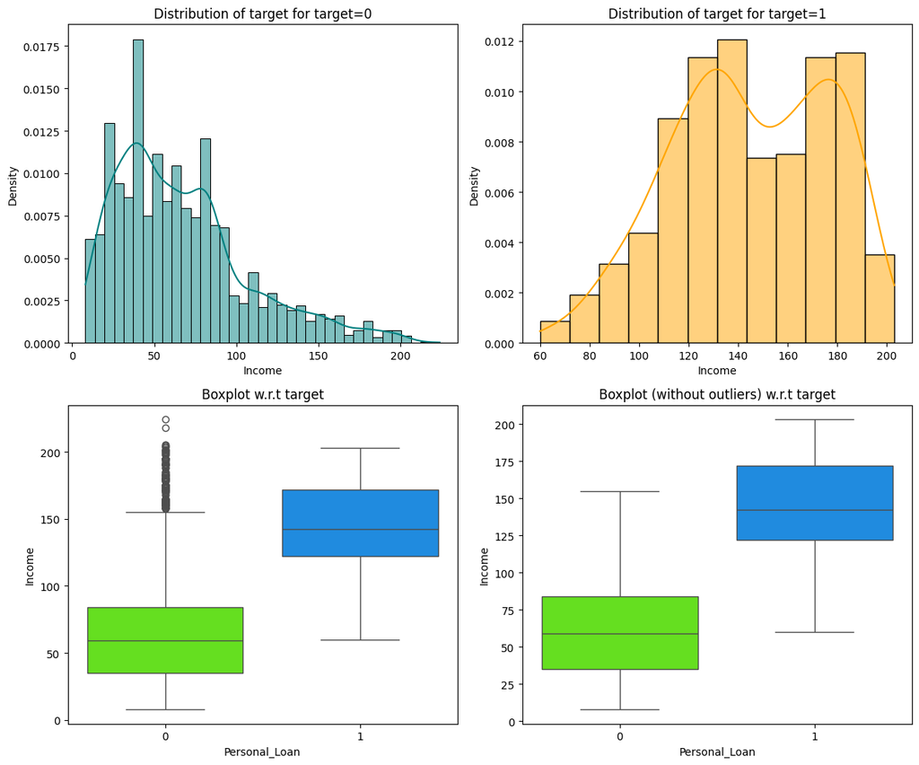

```python
distribution_plot_wrt_target(ldata,'Income','Personal_Loan')
```

- Mean Income for the customers who accept the loan was approximately USD $145K & the customers who don't have the loan have mean income as approximately USD 65K
- This confirms that customer income level will have a high impact on the personal loan, higher the income then likelihood of customer accepting loan is also high

**Personal Loan Vs CCAvg**

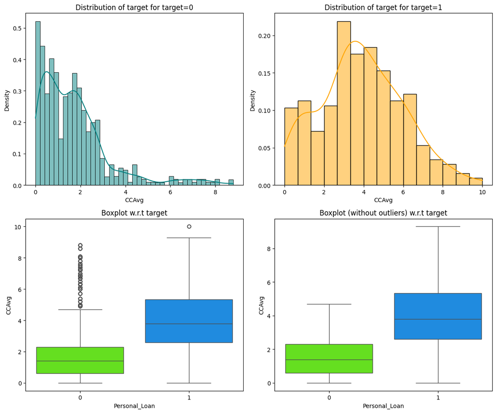

```python
distribution_plot_wrt_target(ldata,'CCAvg','Personal_Loan')
```

- Mean CCAvg of the customers who don't accept the loan is nearly USD 1.5K whereas mean CCAvg of the customers who accept the loan is nearly USD 4K
- This shows the customers who accept the loan is spending more on credit cards per month

**Personal Loan Vs Mortgage**

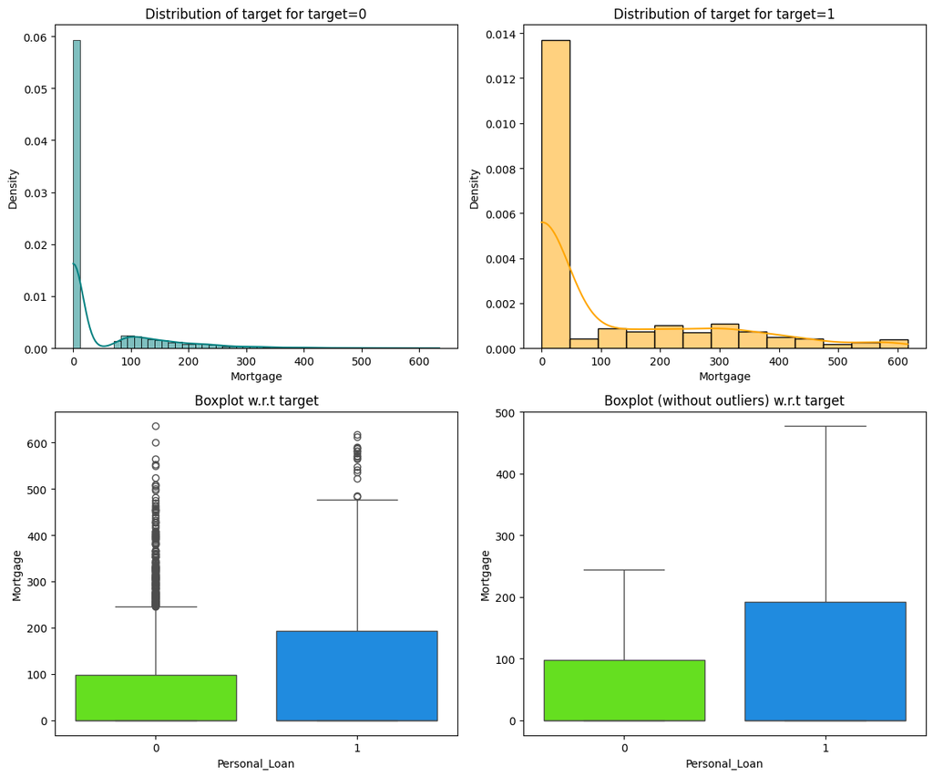

```python
distribution_plot_wrt_target(ldata,'Mortgage','Personal_Loan')
```

- Customers who are paying Mortgage are more likely to accept the loan then the customers who are not paying Mortgage
- As the mortgage increases, the likelihood of the customer accepting loan is also high

**Let's check Customers interest in purchasing a loan with Categorical variables**

**Personal_Loan Vs Family**

```
Personal_Loan     0    1   All
Family
All            4520  480  5000
4              1088  134  1222
3               877  133  1010
1              1365  107  1472
2              1190  106  1296
------------------------------------------------------------------------------------------------------------------------
```

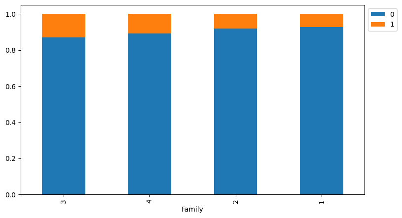

```python
stacked_barplot(ldata, "Family", "Personal_Loan")
plt.show()
```

**Personal_Loan Vs Education**

```
Personal_Loan     0    1   All
Education
All            4520  480  5000
3              1296  205  1501
2              1221  182  1403
1              2003   93  2096
------------------------------------------------------------------------------------------------------------------------
```

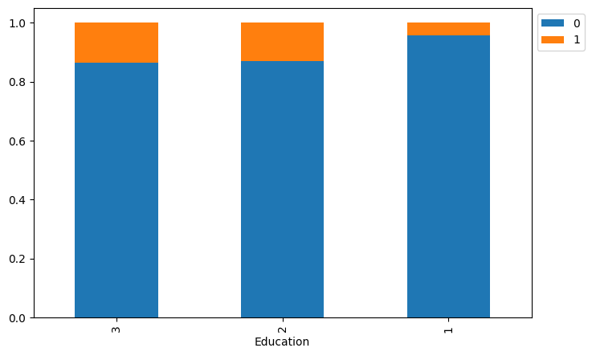

```python
stacked_barplot(ldata, "Education", "Personal_Loan")
```

- Customers with education level as Advanced Professionals & Graduate are more likely to accept the loan. This suggests that individuals with higher educational qualifications often have greater financial needs and are more financially active, frequently using credit cards and applying for loans.

**Personal Loan Vs Securities_Account**

```
Personal_Loan          0    1   All
Securities_Account
All                 4520  480  5000
0                   4058  420  4478
1                    462   60   522
------------------------------------------------------------------------------------------------------------------------
```

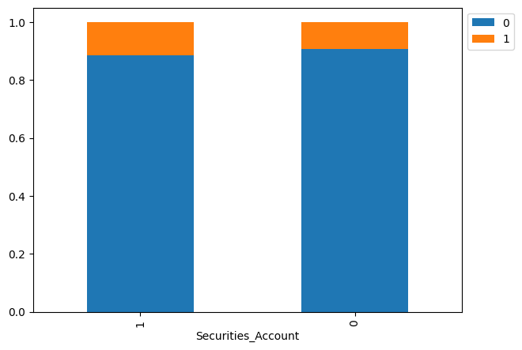

```python
stacked_barplot(ldata, "Securities_Account", "Personal_Loan")
```

- Customers with Securities account with bank are more willing to accept the loan

**Personal Loan Versus CD_Account**

```
Personal_Loan     0    1   All
CD_Account
All            4520  480  5000
0              4358  340  4698
1               162  140   302
------------------------------------------------------------------------------------------------------------------------
```

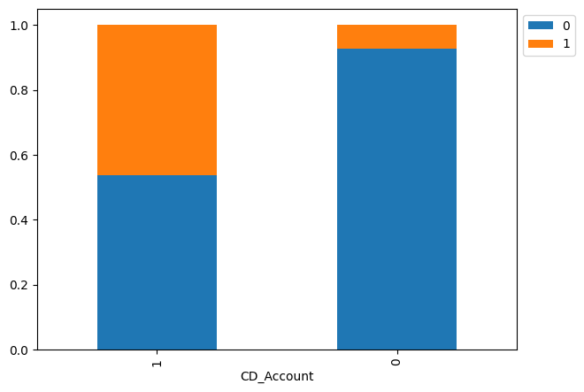

```python
stacked_barplot(ldata, "CD_Account", "Personal_Loan")
```

- Customers who has CD (Certificate of Deposit) with the bank are more likely to accept the Personal loan

**Personal Loan Vs Online**

```
Personal_Loan     0    1   All
Online
All            4520  480  5000
1              2693  291  2984
0              1827  189  2016
------------------------------------------------------------------------------------------------------------------------
```

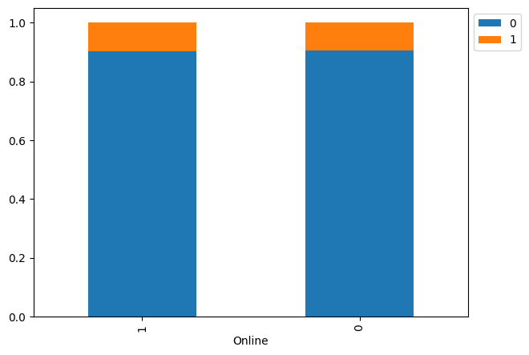

```python
stacked_barplot(ldata, "Online", "Personal_Loan")
```

- We can observe that customers who are using Internet banking faciliites / who are not using internet banking facilities are equal in willing to accept the personal loan

**Personal Loan Vs CreditCard**

```
Personal_Loan     0    1   All
CreditCard
All            4520  480  5000
0              3193  337  3530
1              1327  143  1470
------------------------------------------------------------------------------------------------------------------------
```

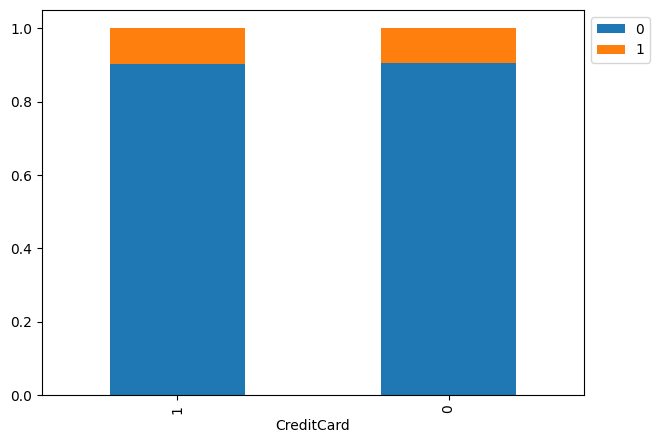

```python
stacked_barplot(ldata, "CreditCard", "Personal_Loan")
```

- Customers using credit card issued by any other Bank / who are not using are equal in willing to accept the personal Loan

**Questions**:

1. What is the distribution of mortgage attribute? Are there any noticeable patterns or outliers in the distribution?
- *Minimum value as USD 0K, Max is USD 635K & average is USD 56K Mortgage is heavily right skewed with multiple outliers*
1. How many customers have credit cards?

```python
print(ldata['CreditCard'].value_counts())
ldata['CreditCard'].value_counts(normalize=True)
```

```
CreditCard
0    3530
1    1470
Name: count, dtype: int64
```

```
CreditCard
0    0.706
1    0.294
Name: proportion, dtype: float64
```

*1470(29.4%) customers have credit card*

## Data Preprocessing (contd..)

**Outlier Detection**

```python
ldata.info()
```

```
<class 'pandas.core.frame.DataFrame'>
RangeIndex: 5000 entries, 0 to 4999
Data columns (total 13 columns):
 #   Column              Non-Null Count  Dtype
---  ------              --------------  -----
 0   Age                 5000 non-null   int64
 1   Experience          5000 non-null   int64
 2   Income              5000 non-null   int64
 3   ZIPCode             5000 non-null   category
 4   Family              5000 non-null   int64
 5   CCAvg               5000 non-null   float64
 6   Education           5000 non-null   category
 7   Mortgage            5000 non-null   int64
 8   Personal_Loan       5000 non-null   category
 9   Securities_Account  5000 non-null   category
 10  CD_Account          5000 non-null   category
 11  Online              5000 non-null   category
 12  CreditCard          5000 non-null   category
dtypes: category(7), float64(1), int64(5)
memory usage: 269.8 KB
```

```python
# let's find out percentile values for all numerical columns

num_cols =['Age','Experience','Income','Family','CCAvg','Mortgage']
```

```python
# Let's find out 25th and 75th percentile values
Q1 = ldata[num_cols].quantile(0.25)
Q3 = ldata[num_cols].quantile(0.75)
# Inter Quantile Range
IQR = Q3 - Q1

lower = (
    Q1 - 1.5 * IQR
)  # Finding lower and upper bounds for all values. All values outside these bounds are outliers
upper = Q3 + 1.5 * IQR
```

```python
(
    (ldata.select_dtypes(include=["float64", "int64"]) < lower)
    | (ldata.select_dtypes(include=["float64", "int64"]) > upper)
).sum() / len(ldata) * 100
```

```
Age           0.00
Experience    0.00
Income        1.92
Family        0.00
CCAvg         6.48
Mortgage      5.82
dtype: float64
```

Outliers exists in Income, CCAvg & Mortgage features These Outliers may represent real scenarios, so they won't be treated separately.

### Data Preparation for Modeling

```python
X = ldata.drop("Personal_Loan", axis=1)
Y = ldata["Personal_Loan"]

X = pd.get_dummies(X, columns=["ZIPCode", "Education"], drop_first=True)

# Splitting data in train and test sets
X_train, X_test, y_train, y_test = train_test_split(
    X, Y, test_size=0.30, random_state=1
)
```

```python
print("Training Set Shape : ", X_train.shape)
print("Test Set Shape: ", X_test.shape)
print("Training set percentage")
print(y_train.value_counts(normalize=True))
print("Test set percentage")
print(y_test.value_counts(normalize=True))
```

```
Training Set Shape :  (3500, 18)
Test Set Shape:  (1500, 18)
Training set percentage
Personal_Loan
0    0.905429
1    0.094571
Name: proportion, dtype: float64
Test set percentage
Personal_Loan
0    0.900667
1    0.099333
Name: proportion, dtype: float64
```

## Model Building

### Model Evaluation Criterion

We have two cases here:

Case 1: We predict a customer will accept the loan, but in reality, they don't accept the loan, leading to wasted resources on those customers - False Positive.

Case 2: We predict a customer will not accept the loan, but in reality, they do accept the loan, resulting in a loss of opportunity - False Negative.

In this scenario, our primary concern is reducing False Negatives, which means we need to increase the Recall value.

### Model Building

Let's first create the following functions to calculate different metrics and the confusion matrix, which can be reused for all the different models that we are testing.

- The model_performance_classification_sklearn function will be used to check the model performance of models.
- The confusion_matrix_sklearnfunction will be used to plot confusion matrix.

```python
# defining a function to compute different metrics to check performance of a classification model built using sklearn
def model_performance_classification_sklearn(model, predictors, target):
    """
    Function to compute different metrics to check classification model performance

    model: classifier
    predictors: independent variables
    target: dependent variable
    """

    # predicting using the independent variables
    predict = model.predict(predictors)

    accuracy = accuracy_score(target, predict)  # to compute Accuracy
    recall = recall_score(target, predict)  # to compute Recall
    precision = precision_score(target, predict)  # to compute Precision
    f1 = f1_score(target, predict)  # to compute F1-score

    # creating a dataframe of metrics
    df_perf = pd.DataFrame(
        {"Accuracy": accuracy, "Recall": recall, "Precision": precision, "F1": f1,},
        index=[0],
    )

    return df_perf
```

```python
def confusion_matrix_sklearn(model, predictors, target):
    """
    To plot the confusion_matrix with percentages

    model: classifier
    predictors: independent variables
    target: dependent variable
    """
    y_pred = model.predict(predictors)
    cm = confusion_matrix(target, y_pred)
    labels = np.asarray(
        [
            ["{0:0.0f}".format(item) + "\n{0:.2%}".format(item / cm.flatten().sum())]
            for item in cm.flatten()
        ]
    ).reshape(2, 2)

    plt.figure(figsize=(6, 4))
    sns.heatmap(cm, annot=labels, fmt="")
    plt.ylabel("True label")
    plt.xlabel("Predicted label")
```

**Build Decision Tree Model**

```python
model = DecisionTreeClassifier(criterion="gini", random_state=1)
model.fit(X_train, y_train)
```

```
DecisionTreeClassifier(random_state=1)
```

**Checking Model Performance on Train data**

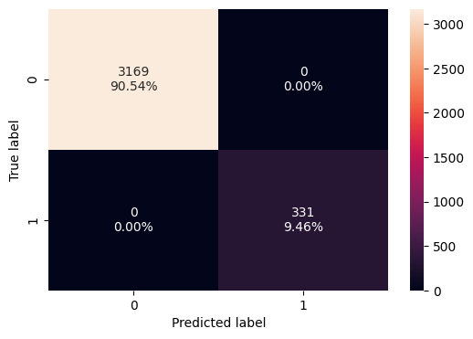

```python
confusion_matrix_sklearn(model, X_train, y_train)
```

```python
decision_tree_perf_train = model_performance_classification_sklearn(
    model, X_train, y_train
)
decision_tree_perf_train
```

|  | Accuracy | Recall | Precision | F1 |
| --- | --- | --- | --- | --- |
| 0 | 1.0 | 1.0 | 1.0 | 1.0 |

This indicates that the model is overfitting the data. Both False Negatives and False Positives are completely zero, and all metrics are showing 100%.

Visualizing the Decision Tree

```python
feature_names = list(X_train.columns)
print(feature_names)
```

```
['Age', 'Experience', 'Income', 'Family', 'CCAvg', 'Mortgage', 'Securities_Account', 'CD_Account', 'Online', 'CreditCard', 'ZIPCode_91', 'ZIPCode_92', 'ZIPCode_93', 'ZIPCode_94', 'ZIPCode_95', 'ZIPCode_96', 'Education_2', 'Education_3']
```

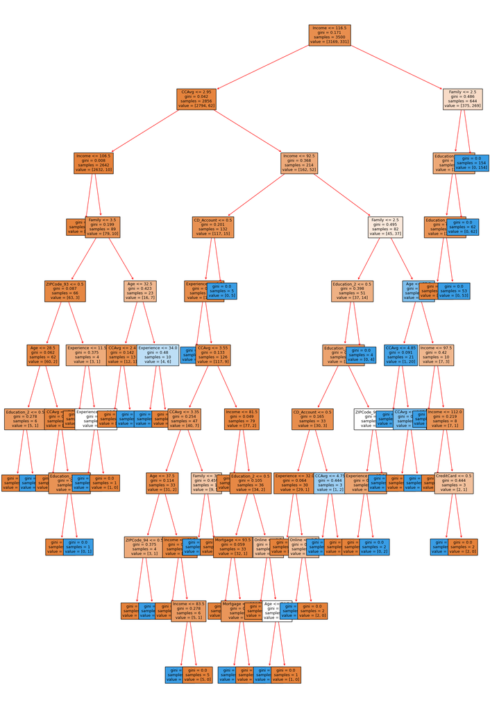

```python
plt.figure(figsize=(20, 30))
out = tree.plot_tree(
    model,
    feature_names=feature_names,
    filled=True,
    fontsize=9,
    node_ids=False,
    class_names=None,
)
# below code will add arrows to the decision tree split if they are missing
for o in out:
    arrow = o.arrow_patch
    if arrow is not None:
        arrow.set_edgecolor("Red")
        arrow.set_linewidth(1)
plt.show()
```

From this decision tree, we observe that the initial split was on income. Let's analyze this tree by generating a text-based report.

```python
# Text report showing the rules of a decision tree -

print(tree.export_text(model, feature_names=feature_names, show_weights=True))
```

```
|--- Income <= 116.50
|   |--- CCAvg <= 2.95
|   |   |--- Income <= 106.50
|   |   |   |--- weights: [2553.00, 0.00] class: 0
|   |   |--- Income >  106.50
|   |   |   |--- Family <= 3.50
|   |   |   |   |--- ZIPCode_93 <= 0.50
|   |   |   |   |   |--- Age <= 28.50
|   |   |   |   |   |   |--- Education_2 <= 0.50
|   |   |   |   |   |   |   |--- weights: [5.00, 0.00] class: 0
|   |   |   |   |   |   |--- Education_2 >  0.50
|   |   |   |   |   |   |   |--- weights: [0.00, 1.00] class: 1
|   |   |   |   |   |--- Age >  28.50
|   |   |   |   |   |   |--- CCAvg <= 2.20
|   |   |   |   |   |   |   |--- weights: [48.00, 0.00] class: 0
|   |   |   |   |   |   |--- CCAvg >  2.20
|   |   |   |   |   |   |   |--- Education_3 <= 0.50
|   |   |   |   |   |   |   |   |--- weights: [7.00, 0.00] class: 0
|   |   |   |   |   |   |   |--- Education_3 >  0.50
|   |   |   |   |   |   |   |   |--- weights: [0.00, 1.00] class: 1
|   |   |   |   |--- ZIPCode_93 >  0.50
|   |   |   |   |   |--- Experience <= 11.50
|   |   |   |   |   |   |--- weights: [2.00, 0.00] class: 0
|   |   |   |   |   |--- Experience >  11.50
|   |   |   |   |   |   |--- Experience <= 16.50
|   |   |   |   |   |   |   |--- weights: [0.00, 1.00] class: 1
|   |   |   |   |   |   |--- Experience >  16.50
|   |   |   |   |   |   |   |--- weights: [1.00, 0.00] class: 0
|   |   |   |--- Family >  3.50
|   |   |   |   |--- Age <= 32.50
|   |   |   |   |   |--- CCAvg <= 2.40
|   |   |   |   |   |   |--- weights: [12.00, 0.00] class: 0
|   |   |   |   |   |--- CCAvg >  2.40
|   |   |   |   |   |   |--- weights: [0.00, 1.00] class: 1
|   |   |   |   |--- Age >  32.50
|   |   |   |   |   |--- Experience <= 34.00
|   |   |   |   |   |   |--- weights: [0.00, 6.00] class: 1
|   |   |   |   |   |--- Experience >  34.00
|   |   |   |   |   |   |--- weights: [4.00, 0.00] class: 0
|   |--- CCAvg >  2.95
```

[output cut: 90 more lines]

```
|   |   |   |   |   |   |   |--- CreditCard <= 0.50
|   |   |   |   |   |   |   |   |--- weights: [0.00, 1.00] class: 1
|   |   |   |   |   |   |   |--- CreditCard >  0.50
|   |   |   |   |   |   |   |   |--- weights: [2.00, 0.00] class: 0
|--- Income >  116.50
|   |--- Family <= 2.50
|   |   |--- Education_3 <= 0.50
|   |   |   |--- Education_2 <= 0.50
|   |   |   |   |--- weights: [375.00, 0.00] class: 0
|   |   |   |--- Education_2 >  0.50
|   |   |   |   |--- weights: [0.00, 53.00] class: 1
|   |   |--- Education_3 >  0.50
|   |   |   |--- weights: [0.00, 62.00] class: 1
|   |--- Family >  2.50
|   |   |--- weights: [0.00, 154.00] class: 1
```

```python
# importance of features in the tree building ( The importance of a feature is computed as the
# (normalized) total reduction of the criterion brought by that feature. It is also known as the Gini importance )

print(
    pd.DataFrame(
        model.feature_importances_, columns=["Imp"], index=X_train.columns
    ).sort_values(by="Imp", ascending=False)
)
```

```
                         Imp
Income              0.306022
Family              0.257587
Education_2         0.166192
Education_3         0.147127
CCAvg               0.051023
Experience          0.019556
Age                 0.017394
CD_Account          0.017273
ZIPCode_94          0.008991
Mortgage            0.003236
Online              0.002781
CreditCard          0.002224
ZIPCode_93          0.000594
Securities_Account  0.000000
ZIPCode_91          0.000000
ZIPCode_92          0.000000
ZIPCode_95          0.000000
ZIPCode_96          0.000000
```

The top 5 important features are Income, Family, Education_2, Education_3, CCAvg

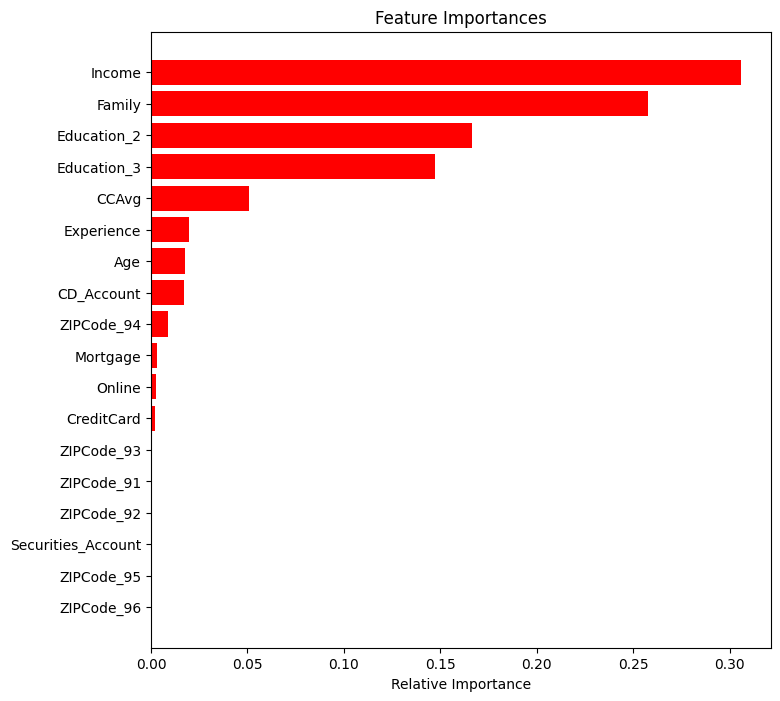

```python
#Let's plot the feature importances graphically

importances = model.feature_importances_
indices = np.argsort(importances)

plt.figure(figsize=(8, 8))
plt.title("Feature Importances")
plt.barh(range(len(indices)), importances[indices], color="red", align="center")
plt.yticks(range(len(indices)), [feature_names[i] for i in indices])
plt.xlabel("Relative Importance")
plt.show()
```

From this we can see the least important features are ZIPCodes, Securities_Account

**Checking Model Performance on test data**

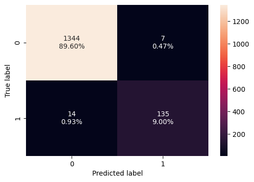

```python
confusion_matrix_sklearn(model, X_test, y_test)
```

```python
decision_tree_perf_test = model_performance_classification_sklearn(model, X_test, y_test)
decision_tree_perf_test
```

|  | Accuracy | Recall | Precision | F1 |
| --- | --- | --- | --- | --- |
| 0 | 0.986 | 0.90604 | 0.950704 | 0.927835 |

This shows that the Recall is 90%. Additionally, we've observed that the model is overfitting the data during training. Therefore, both pre-pruning and post-pruning should be considered to enhance the model's performance.

### Model Performance Improvement

**Pre-Pruning using Hyperparameters tuning**

- Hyperparameter tuning is also tricky in the sense that there is no direct way to calculate how a change in the hyperparameter value will reduce the loss of your model, so we usually resort to experimentation. i.e we'll use Grid search
- Grid search is a tuning technique that attempts to compute the optimum values of hyperparameters.
- It is an exhaustive search that is performed on a the specific parameter values of a model.
- The parameters of the estimator/model used to apply these methods are optimized by cross-validated grid-search over a parameter grid.

```python
# Choose the type of classifier.
estimator = DecisionTreeClassifier(random_state=1)

# Grid of parameters to choose from
parameters = {
    "max_depth": np.arange(1,10),
    "criterion": ["gini"],
    "splitter": ["best", "random"],
    "min_samples_leaf": [1, 2, 5, 7, 10],
    "max_leaf_nodes": [2, 3, 5, 10],
    "min_impurity_decrease": [0.000001, 0.00001, 0.0001],
}

# Type of scoring used to compare parameter combinations
acc_scorer = make_scorer(recall_score)

# Run the grid search
grid_obj = GridSearchCV(estimator, parameters, scoring=acc_scorer, cv=5)
grid_obj = grid_obj.fit(X_train, y_train)

# Set the clf to the best combination of parameters
estimator = grid_obj.best_estimator_

# Fit the best algorithm to the data.
estimator.fit(X_train, y_train)
```

```
DecisionTreeClassifier(max_depth=6, max_leaf_nodes=10,
                       min_impurity_decrease=1e-06, min_samples_leaf=10,
                       random_state=1)
```

**Checking performance on the training data**

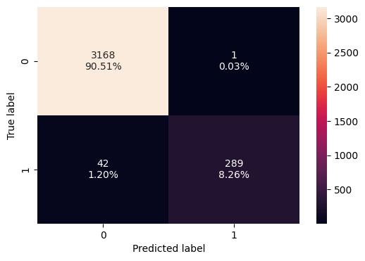

```python
confusion_matrix_sklearn(estimator, X_train, y_train)
```

```python
decision_tree_tune_perf_train = model_performance_classification_sklearn(
    estimator, X_train, y_train
)
decision_tree_tune_perf_train
```

|  | Accuracy | Recall | Precision | F1 |
| --- | --- | --- | --- | --- |
| 0 | 0.987714 | 0.873112 | 0.996552 | 0.930757 |

After prepruning we notice the recall has is around 87%

**Visualizing the Decision Tree**

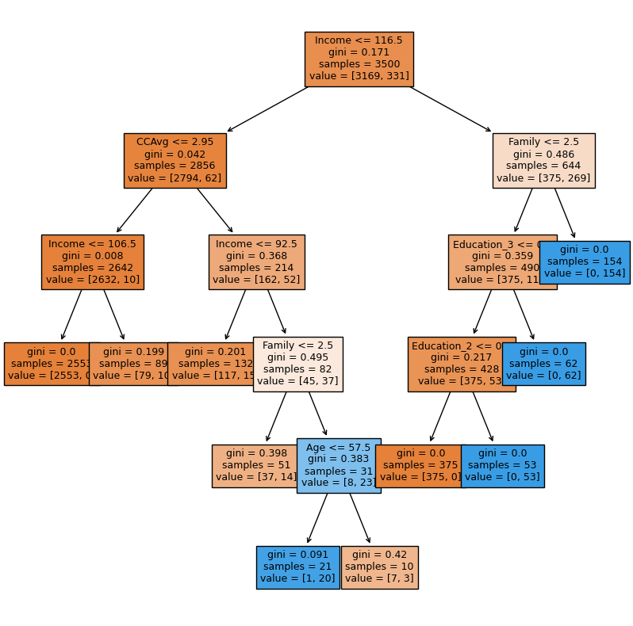

```python
plt.figure(figsize=(10, 10))
out = tree.plot_tree(
    estimator,
    feature_names=feature_names,
    filled=True,
    fontsize=9,
    node_ids=False,
    class_names=None,
)
# below code will add arrows to the decision tree split if they are missing
for o in out:
    arrow = o.arrow_patch
    if arrow is not None:
        arrow.set_edgecolor("black")
        arrow.set_linewidth(1)
plt.show()
```

```python
# Text report showing the rules of a decision tree -

print(tree.export_text(estimator, feature_names=feature_names, show_weights=True))
```

```
|--- Income <= 116.50
|   |--- CCAvg <= 2.95
|   |   |--- Income <= 106.50
|   |   |   |--- weights: [2553.00, 0.00] class: 0
|   |   |--- Income >  106.50
|   |   |   |--- weights: [79.00, 10.00] class: 0
|   |--- CCAvg >  2.95
|   |   |--- Income <= 92.50
|   |   |   |--- weights: [117.00, 15.00] class: 0
|   |   |--- Income >  92.50
|   |   |   |--- Family <= 2.50
|   |   |   |   |--- weights: [37.00, 14.00] class: 0
|   |   |   |--- Family >  2.50
|   |   |   |   |--- Age <= 57.50
|   |   |   |   |   |--- weights: [1.00, 20.00] class: 1
|   |   |   |   |--- Age >  57.50
|   |   |   |   |   |--- weights: [7.00, 3.00] class: 0
|--- Income >  116.50
|   |--- Family <= 2.50
|   |   |--- Education_3 <= 0.50
|   |   |   |--- Education_2 <= 0.50
|   |   |   |   |--- weights: [375.00, 0.00] class: 0
|   |   |   |--- Education_2 >  0.50
|   |   |   |   |--- weights: [0.00, 53.00] class: 1
|   |   |--- Education_3 >  0.50
|   |   |   |--- weights: [0.00, 62.00] class: 1
|   |--- Family >  2.50
|   |   |--- weights: [0.00, 154.00] class: 1
```

```python
# importance of features in the tree building ( The importance of a feature is computed as the
# (normalized) total reduction of the criterion brought by that feature. It is also known as the Gini importance )

print(
    pd.DataFrame(
        estimator.feature_importances_, columns=["Imp"], index=X_train.columns
    ).sort_values(by="Imp", ascending=False)
)
```

```
                         Imp
Income              0.337681
Family              0.275581
Education_2         0.175687
Education_3         0.157286
CCAvg               0.042856
Age                 0.010908
Securities_Account  0.000000
CD_Account          0.000000
Online              0.000000
Experience          0.000000
ZIPCode_91          0.000000
ZIPCode_92          0.000000
ZIPCode_93          0.000000
ZIPCode_94          0.000000
ZIPCode_95          0.000000
ZIPCode_96          0.000000
Mortgage            0.000000
CreditCard          0.000000
```

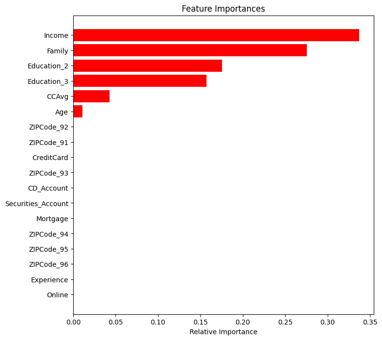

```python
importances = estimator.feature_importances_
indices = np.argsort(importances)

plt.figure(figsize=(8, 8))
plt.title("Feature Importances")
plt.barh(range(len(indices)), importances[indices], color="red", align="center")
plt.yticks(range(len(indices)), [feature_names[i] for i in indices])
plt.xlabel("Relative Importance")
plt.show()
```

From this prepruning we could see the features Income , Family, Education_2, Education_3 & CCAvg are still important features for our model